# STAT 240 Discussion 6

## Members Present

- SHRUTHI SRINIVASAN, ZHENG MA, ZILING HU
- **HAOXUAN LU**

## Create Data Frames

Make data frames that also have an index variable which is the row number.

```r
df_words = tibble(
  index = seq_along(stringr::words),
  words = stringr::words)

df_colors = tibble(
  index = seq_along(colors()),
  colors = colors())
```

### 1

> Find the lengths of all strings in `df_words` and make a histogram that shows the number of words for each length. Use wise choices for the boundary and binwidth. *(Hint: use `mutate()` to add a column to `df_words` and use `str_length()` to calculate the value to put into this column.)*

> After making a histogram, make a bar chart with the same information. Which do you prefer and why?

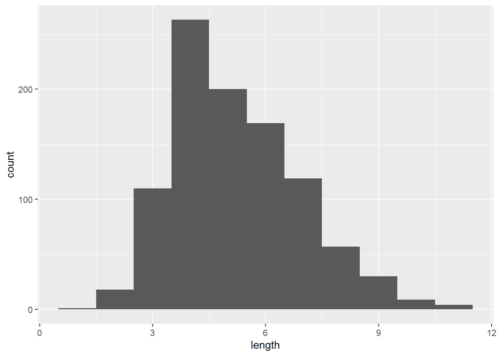

```r
df_words_len <- df_words %>%
  mutate(length = str_length(words))

ggplot(data = df_words_len) +
  geom_histogram(mapping = aes(x = length), center = 6, binwidth = 1)
```

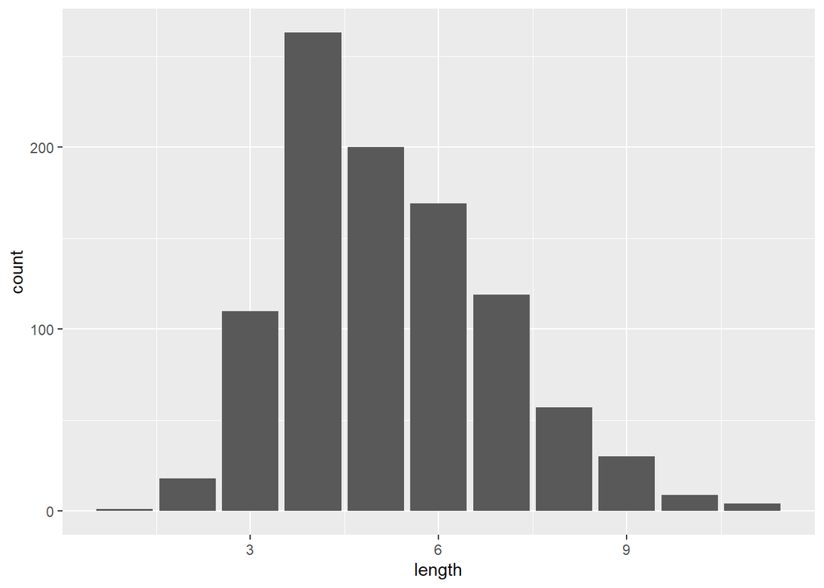

```r
ggplot(data = df_words_len) +
  geom_bar(mapping = aes(x = length))
```

### Response

- It seems two plots are the same. The histogram displays a range for the length of string like [3,4), while the barplot displays the whole number of the length of string like 3 or 4. So the barplot can be better.

### 2

> The R command `colors()` returns an array with all of the color names that R knows about. Filter to find all colors that contain the pattern “red”. *(Hint: use `str_detect()`.)*. Report the number of colors and the first and last of these alphabetically.

```r
df_colors %>%
  filter(str_detect(colors, "red")) %>%
  arrange(colors)
```

```
## # A tibble: 27 x 2
##    index colors
##    <int> <chr>
##  1   100 darkred
##  2   372 indianred
##  3   373 indianred1
##  4   374 indianred2
##  5   375 indianred3
##  6   376 indianred4
##  7   476 mediumvioletred
##  8   503 orangered
##  9   504 orangered1
## 10   505 orangered2
## # ... with 17 more rows
```

### Response

- There are 27 colors contain the pattern “red”. The first is “darkred” and the last is “violetred4”

### 3

> How many words in `df_words` begin with each letter? Do not distinguish between lower case and capital letters. Make a bar graph that displays these counts. Then repeat for the last letter of each word. *(Hint: use `mutate()` and `str_sub()` to create new columns with the first and last letter of each word and then make the graphs. Use either `str_to_lower()` or `str_to_upper()` to before counting.)*

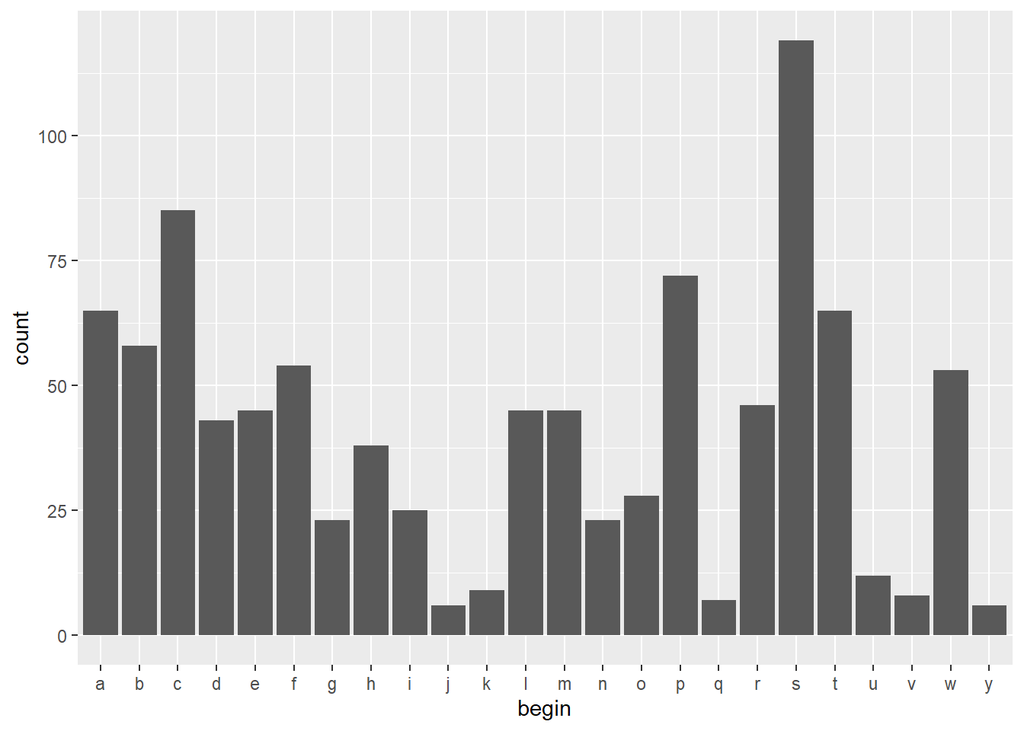

```r
df_begin_end <- df_words %>%
  mutate(begin = str_to_lower(str_sub(words, 1 , 1)), end = str_to_lower(str_sub(words, -1, -1)))

df_begin_end %>%
  group_by(begin) %>%
  summarise(count = n()) %>%
  ggplot() +
  geom_col(mapping = aes(x = begin, y = count))
```

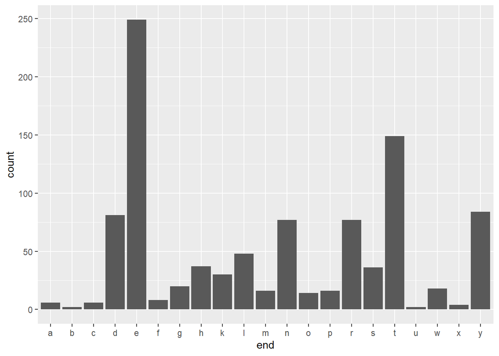

```r
df_begin_end %>%
  group_by(end) %>%
  summarise(count = n()) %>%
  ggplot() +
  geom_col(mapping = aes(x = end, y = count))
```

### 4

> Find all words in `df_words` that begin and end with the most popular letter (regardless of capitalization) for each position. Report the number of such words and the first and last in alphabetical order. *(Hint: Use `filter()` with `str_detect()` and a regular expression to identify the words. Then use `summarize()` to answer the questions.)*

```r
df_begin_end %>%
  group_by(begin) %>%
  summarise(count = n()) %>%
  arrange(desc(count)) # the most popular begin is letter "s"
```

```
## # A tibble: 24 x 2
##    begin count
##    <chr> <int>
##  1 s       119
##  2 c        85
##  3 p        72
##  4 a        65
##  5 t        65
##  6 b        58
##  7 f        54
##  8 w        53
##  9 r        46
## 10 e        45
## # ... with 14 more rows
```

```r
df_begin_end %>%
  group_by(end) %>%
  summarise(count = n()) %>%
  arrange(desc(count)) # the most popular end is letter "e"
```

```
## # A tibble: 21 x 2
##    end   count
##    <chr> <int>
##  1 e       249
##  2 t       149
##  3 y        84
##  4 d        81
##  5 n        77
##  6 r        77
##  7 l        48
##  8 h        37
##  9 s        36
## 10 k        30
## # ... with 11 more rows
```

```r
df_s_e <- df_words %>%
  filter(str_detect(words, "^s.+e$")) %>%
  arrange(words)
df_s_e
```

```
## # A tibble: 35 x 2
##    index words
##    <int> <chr>
##  1   718 safe
##  2   719 sale
##  3   720 same
##  4   722 save
##  5   724 scheme
##  6   726 science
##  7   727 score
##  8   733 secure
##  9   734 see
## 10   739 sense
## # ... with 25 more rows
```

```r
df_s_e%>%
  summarise(count = n())
```

```
## # A tibble: 1 x 1
##   count
##   <int>
## 1    35
```

### Response

- There are 35 such words and the first one is “safe” and the last one is “surprise”

### 5

> Find and display all words in `df_words` that begin with a capital letter. Then, write them with that letter replaced by a lower case letter. How many such words are there? *(Hint: Use `filter()` and `str_detect()` with a regular expression involving `^[:upper:]`) to find the words and `str_c()`, `str_to_lower()` and `str_sub()` inside of `mutate()` to solve the problem.)*

```r
df_upper <- df_words %>%
  filter(str_detect(words, "^[:upper:]"))

df_upper %>%
  mutate(words = str_c(str_to_lower(str_sub(words, 1, 1)), str_sub(words, 2, -1)))
```

```
## # A tibble: 2 x 2
##   index words
##   <int> <chr>
## 1   150 christ
## 2   151 christmas
```

### Response

- There are 2 words.

### 6

> Create a string named `color_string` which has all of the colors in `df_colors()` that do not contain digits separated by the symbol `|` arranged alphabetically. How many such colors are there? Display the first 30 characters of `color_string`. *(Hint: Use `str_detect()` and `[:digit:]` to `filter()` the appropriate rows, `pull()` to extract a column as a vector, and `str_c()` with argument `collapse` set appropriately.)*

```r
df_color_nodigit <- df_colors %>%
  filter(!str_detect(colors, "[:digit:]")) %>%
  arrange(colors)
df_color_nodigit
```

```
## # A tibble: 143 x 2
##    index colors
##    <int> <chr>
##  1     2 aliceblue
##  2     3 antiquewhite
##  3     8 aquamarine
##  4    13 azure
##  5    18 beige
##  6    19 bisque
##  7    24 black
##  8    25 blanchedalmond
##  9    26 blue
## 10    31 blueviolet
## # ... with 133 more rows
```

```r
color_string <- str_c(df_color_nodigit %>%
  pull(), collapse = "|")
str_sub(color_string, 1, 30)
```

```
## [1] "aliceblue|antiquewhite|aquamar"
```

### Response

- There are 143 colors

### 7

> Find all words in `df_words` that match a color in `color_string` exactly. Display the list. How many such words are there? *(Hint: Use `str_match()` inside of `mutate()` to create a column named `match` which saves the pattern where `words` matches `color_string`, drop missing values, and then `filter()` to keep only those cases where there is an exact match between the word and the matching pattern.)*

```r
df_words %>%
  mutate(match = str_match(words, color_string)) %>%
  drop_na() %>%
  filter(words == match)
```

```
## # A tibble: 5 x 3
##   index words match[,1]
##   <int> <chr> <chr>
## 1    95 black black
## 2    99 blue  blue
## 3   368 green green
## 4   690 red   red
## 5   949 white white
```

### Response

- There are 5 words